# Comments for MEDB 5501, Week 14

## Topics to be covered

- What you will learn
  - Interpretation of regression slope and intercept
  - Relationship to the correlation coefficient
  - Definition of residuals
  - Calculation of sums of squares
  - Proportion of explained variation
  - Assumptions in linear regression
  - Interpretation with two independent variables

## Algebra formula for a straight line

- $Y=mx+b$
- $m = \Delta y / \Delta x$
- m = slope
- b = y-intercept

## Linear regression interpretation of a straight line

- The slope represents the estimated average change in Y when X increases by one unit.
- The intercept represents the estimated average value of Y when X equals zero.

## First regression example with interpretation

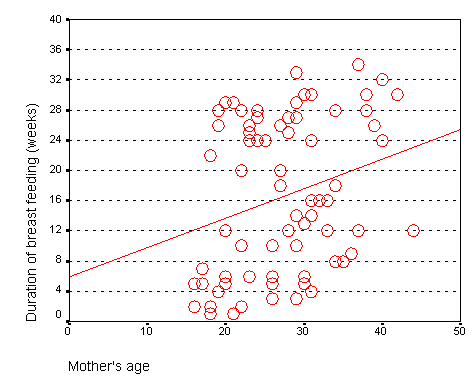

## Output from SPSS

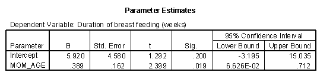

## Interpretation when X is categorical

- Code X as 0-1
- Intercept: Estimated average value of Y for the “0” category.
- Slope: Estimated average change in Y when category changes from “0” to “1”.

## Second regression example with interpretation

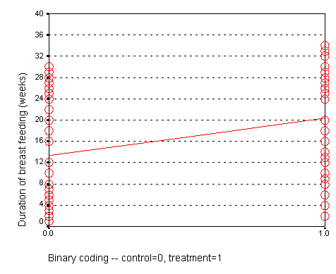

## SPSS output

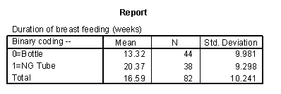

## Alternate coding

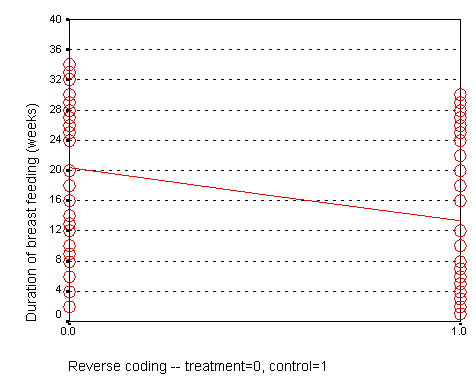

Figure 5. Scatterplot with alternate ordering of treatment

## SPSS output

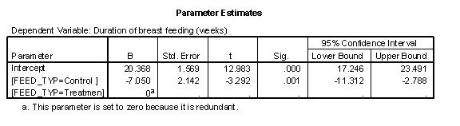

## Break #1

- What you have learned
  - Interpretation of regression slope and intercept
- What’s coming next
  - Relationship to the correlation coefficient

## Relationship to the correlation coefficient

- Recall from the previous module
  - $Cov(X,Y)=\frac{1}{n-1}\Sigma(X_i-\bar{X})(Y_i-\bar{Y})$
  - $r_{XY}=\frac{Cov(X,Y)}{S_X S_Y}$
- This implies that
  - $b_1=r_{XY}\frac{S_Y}{S_X}$

## Important implications

- $r_{XY}$ is unitless, $b_1$ is Y units per X units
- $r_{XY}>0$ implies $b_1>0$
- $r_{XY}=0$ implies $b_1=0$
- $r_{XY}<0$ implies $b_1<0$
  - and vice versa

## Break #2

- What you have learned
  - Relationship to the correlation coefficient
- What’s coming next
  - Definition of residuals

## Artificial data

```
  x  y
  5 29
  7 21
  9 15
 11 25
 13 11
 15 19
```

## Sum of squares regression

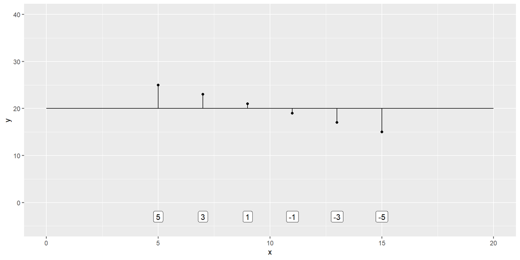

## Sum of squares error

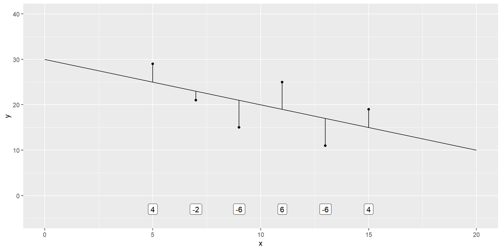

## Sum of squares total / corrected total

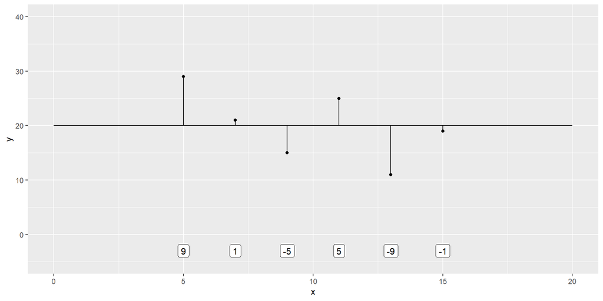